# Immune cell & cytokine dynamics across the menstrual cycle

## Regression models

We fit **linear mixed-effects models** (random intercept per participant) with log-transformed outcomes. Type III ANOVA with Satterthwaite denominator df.

### Model 1: CD45+ immune cells ~ time point × arm

```r
m1 <- lmer(log(cd45_positive) ~ time_point * arm + (1 | pid), data = master)
anova(m1, type = 3) |>
  as.data.frame() |>
  rownames_to_column("Term") |>
  gt() |>
  tab_header(
    title = md("**Model 1.** log(CD45+) ~ time_point × arm"),
    subtitle = "Type III ANOVA (Satterthwaite)"
  ) |>
  fmt_number(columns = c("Sum Sq", "Mean Sq"), decimals = 3) |>
  fmt_number(columns = c("F value"), decimals = 2) |>
  fmt_number(columns = c("Pr(>F)"), decimals = 4)
```

**Model 1.** log(CD45+) ~ time_point × arm

Type III ANOVA (Satterthwaite)

| Term | Sum Sq | Mean Sq | NumDF | DenDF | F value | Pr(>F) |
| --- | --- | --- | --- | --- | --- | --- |
| time_point | 2.069 | 0.690 | 3 | 75 | 1.67 | 0.1802 |
| arm | 0.294 | 0.294 | 1 | 25 | 0.71 | 0.4062 |
| time_point:arm | 0.274 | 0.091 | 3 | 75 | 0.22 | 0.8814 |

**Result:** No significant main effect of time point (F<sub>3,75</sub> = 1.67, p = 0.18), arm (F<sub>1,25</sub> = 0.71, p = 0.41), or their interaction (F<sub>3,75</sub> = 0.22, p = 0.88). CD45+ counts are relatively stable across the cycle regardless of birth control use.

### Model 2: Neutrophils ~ time point × arm

```r
m2 <- lmer(log(neutrophils) ~ time_point * arm + (1 | pid), data = master)
anova(m2, type = 3) |>
  as.data.frame() |>
  rownames_to_column("Term") |>
  gt() |>
  tab_header(
    title = md("**Model 2.** log(Neutrophils) ~ time_point × arm"),
    subtitle = "Type III ANOVA (Satterthwaite)"
  ) |>
  fmt_number(columns = c("Sum Sq", "Mean Sq"), decimals = 3) |>
  fmt_number(columns = c("F value"), decimals = 2) |>
  fmt_number(columns = c("Pr(>F)"), decimals = 4)
```

**Model 2.** log(Neutrophils) ~ time_point × arm

Type III ANOVA (Satterthwaite)

| Term | Sum Sq | Mean Sq | NumDF | DenDF | F value | Pr(>F) |
| --- | --- | --- | --- | --- | --- | --- |
| time_point | 2.313 | 0.771 | 3 | 74.99997 | 1.41 | 0.2456 |
| arm | 0.214 | 0.214 | 1 | 24.99997 | 0.39 | 0.5372 |
| time_point:arm | 0.188 | 0.063 | 3 | 74.99997 | 0.11 | 0.9513 |

**Result:** Same pattern — no significant effects of time point, arm, or their interaction on neutrophil counts.

### Model 3: CD45+ ~ time point × PCOS status

```r
m3 <- lmer(log(cd45_positive) ~ time_point * pcos_status + (1 | pid), data = master)
anova(m3, type = 3) |>
  as.data.frame() |>
  rownames_to_column("Term") |>
  gt() |>
  tab_header(
    title = md("**Model 3.** log(CD45+) ~ time_point × PCOS status"),
    subtitle = "Type III ANOVA (Satterthwaite)"
  ) |>
  fmt_number(columns = c("Sum Sq", "Mean Sq"), decimals = 3) |>
  fmt_number(columns = c("F value"), decimals = 2) |>
  fmt_number(columns = c("Pr(>F)"), decimals = 4)
```

**Model 3.** log(CD45+) ~ time_point × PCOS status

Type III ANOVA (Satterthwaite)

| Term | Sum Sq | Mean Sq | NumDF | DenDF | F value | Pr(>F) |
| --- | --- | --- | --- | --- | --- | --- |
| time_point | 1.937 | 0.646 | 3 | 75 | 1.64 | 0.1874 |
| pcos_status | 0.443 | 0.443 | 1 | 25 | 1.13 | 0.2989 |
| time_point:pcos_status | 1.664 | 0.555 | 3 | 75 | 1.41 | 0.2469 |

**Result:** No significant effects. PCOS status does not independently predict CD45+ cell counts in this sample.

### Model 4: IL-1a ~ time point × arm **← the strongest finding**

```r
il1a_data <- luminex_master |>
  filter(cytokine == "IL-1a", limits == "not_censored")

m4 <- lmer(log(conc) ~ time_point * arm + (1 | pid), data = il1a_data)
anova(m4, type = 3) |>
  as.data.frame() |>
  rownames_to_column("Term") |>
  gt() |>
  tab_header(
    title = md("**Model 4.** log(IL-1a) ~ time_point × arm **"),
    subtitle = "Type III ANOVA (Satterthwaite)"
  ) |>
  fmt_number(columns = c("Sum Sq", "Mean Sq"), decimals = 3) |>
  fmt_number(columns = c("F value"), decimals = 2) |>
  fmt_number(columns = c("Pr(>F)"), decimals = 6)
```

**Model 4.** log(IL-1a) ~ time_point × arm **

Type III ANOVA (Satterthwaite)

| Term | Sum Sq | Mean Sq | NumDF | DenDF | F value | Pr(>F) |
| --- | --- | --- | --- | --- | --- | --- |
| time_point | 103.694 | 34.565 | 3 | 73.77707 | 22.75 | 0.000000 |
| arm | 10.566 | 10.566 | 1 | 24.33962 | 6.96 | 0.014336 |
| time_point:arm | 1.530 | 0.510 | 3 | 73.77707 | 0.34 | 0.799517 |

**Result:** This is our strongest model. **IL-1a varies significantly across the menstrual cycle** (F<sub>3,73.8</sub> = 22.75, p < 0.001) and **differs by birth control arm** (F<sub>1,24.3</sub> = 6.96, p = 0.014). The interaction was not significant. IL-1a peaks sharply at *onset* (menstruation) and at *end_bleeding*, with lower concentrations in the birth control group.

### Model 5: CD4/CD8 ratio ~ time point × arm

```r
m5 <- lmer(log(cd4_cd8_ratio) ~ time_point * arm + (1 | pid), data = master)
anova(m5, type = 3) |>
  as.data.frame() |>
  rownames_to_column("Term") |>
  gt() |>
  tab_header(
    title = md("**Model 5.** log(CD4/CD8 ratio) ~ time_point × arm"),
    subtitle = "Type III ANOVA (Satterthwaite)"
  ) |>
  fmt_number(columns = c("Sum Sq", "Mean Sq"), decimals = 3) |>
  fmt_number(columns = c("F value"), decimals = 2) |>
  fmt_number(columns = c("Pr(>F)"), decimals = 6)
```

**Model 5.** log(CD4/CD8 ratio) ~ time_point × arm

Type III ANOVA (Satterthwaite)

| Term | Sum Sq | Mean Sq | NumDF | DenDF | F value | Pr(>F) |
| --- | --- | --- | --- | --- | --- | --- |
| time_point | 6.175 | 2.058 | 3 | 75 | 9.57 | 0.000020 |
| arm | 0.015 | 0.015 | 1 | 25 | 0.07 | 0.796993 |
| time_point:arm | 0.491 | 0.164 | 3 | 75 | 0.76 | 0.519233 |

**Result:** The CD4/CD8 ratio **changes significantly across cycle time points** (F<sub>3,75</sub> = 9.57, p < 0.001), but no effect of birth control arm or their interaction. The ratio shifts across the cycle, suggesting differential trafficking of helper vs. cytotoxic T cells during menstruation.

### Model summary table

```r
model_list <- list(
  "log(CD45+)" = m1,
  "log(Neutrophils)" = m2,
  "log(IL-1a)" = m4,
  "log(CD4/CD8)" = m5
)

model_rows <- list()
for (nm in names(model_list)) {
  aov <- anova(model_list[[nm]], type = 3)
  for (i in seq_len(nrow(aov))) {
    term <- rownames(aov)[i]
    model_rows[[length(model_rows) + 1]] <- tibble(
      Outcome = nm,
      Term = term,
      F = sprintf("%.2f", aov[i, "F value"]),
      df = paste0(aov[i, "NumDF"], ", ", round(aov[i, "DenDF"], 0)),
      p = sprintf("%.4f", aov[i, "Pr(>F)"]),
      Sig = case_when(
        aov[i, "Pr(>F)"] < 0.001 ~ "***",
        aov[i, "Pr(>F)"] < 0.01 ~ "**",
        aov[i, "Pr(>F)"] < 0.05 ~ "*",
        TRUE ~ "ns"
      )
    )
  }
}

bind_rows(model_rows) |>
  gt(groupname_col = "Outcome") |>
  tab_header(
    title = md("**Table 3.** Mixed-effects model results"),
    subtitle = "Type III ANOVA (Satterthwaite). Fixed effects; random intercept per participant."
  ) |>
  cols_label(Sig = "") |>
  tab_source_note(source_note = "*** p < 0.001, ** p < 0.01, * p < 0.05, ns = not significant")
```

**Table 3.** Mixed-effects model results

Type III ANOVA (Satterthwaite). Fixed effects; random intercept per participant.

| Term | F | df | p |  |
| --- | --- | --- | --- | --- |
| log(CD45+) |  |  |  |  |
| time_point | 1.67 | 3, 75 | 0.1802 | ns |
| arm | 0.71 | 1, 25 | 0.4062 | ns |
| time_point:arm | 0.22 | 3, 75 | 0.8814 | ns |
| log(Neutrophils) |  |  |  |  |
| time_point | 1.41 | 3, 75 | 0.2456 | ns |
| arm | 0.39 | 1, 25 | 0.5372 | ns |
| time_point:arm | 0.11 | 3, 75 | 0.9513 | ns |
| log(IL-1a) |  |  |  |  |
| time_point | 22.75 | 3, 74 | 0.0000 | *** |
| arm | 6.96 | 1, 24 | 0.0143 | * |
| time_point:arm | 0.34 | 3, 74 | 0.7995 | ns |
| log(CD4/CD8) |  |  |  |  |
| time_point | 9.57 | 3, 75 | 0.0000 | *** |
| arm | 0.07 | 1, 25 | 0.7970 | ns |
| time_point:arm | 0.76 | 3, 75 | 0.5192 | ns |

*** p < 0.001, ** p < 0.01, * p < 0.05, ns = not significant

Table 3. Model summary

## Figures (ggpubr-style comparisons)

### Figure 1 — CD45+ immune cells by birth control arm

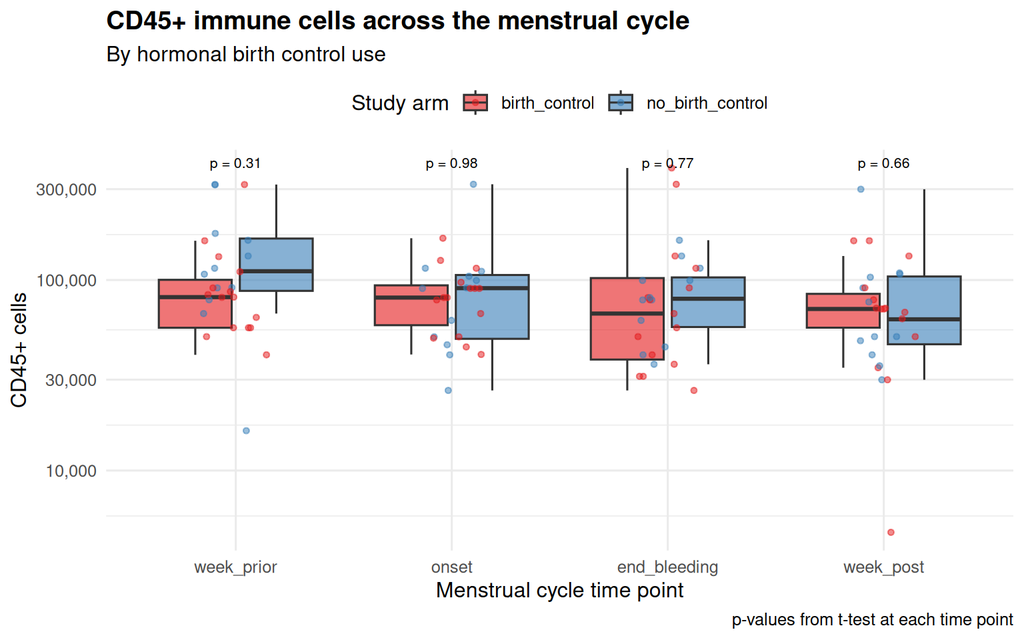

CD45+ immune cells across the menstrual cycle, grouped by hormonal birth control use

```r
arm_colors <- c("birth_control" = "#E41A1C", "no_birth_control" = "#377EB8")

p1 <- master |>
  ggplot(aes(x = time_point, y = cd45_positive, fill = arm)) +
  geom_boxplot(alpha = 0.6, outlier.shape = NA) +
  geom_jitter(aes(color = arm), width = 0.15, alpha = 0.5, size = 1.2) +
  scale_fill_manual(values = arm_colors) +
  scale_color_manual(values = arm_colors) +
  scale_y_log10(labels = scales::comma) +
  labs(
    title = "CD45+ immune cells across the menstrual cycle",
    subtitle = "By hormonal birth control use",
    x = "Menstrual cycle time point",
    y = "CD45+ cells",
    fill = "Study arm",
    color = "Study arm",
    caption = "p-values from t-test at each time point"
  ) +
  theme_minimal(base_size = 12) +
  theme(
    plot.title = element_text(face = "bold"),
    legend.position = "top"
  )

p1 + stat_compare_means(
  aes(group = arm),
  label = "p.format",
  method = "t.test",
  bracket.size = 0.3,
  size = 2.8,
  tip.length = 0.01
)
```

### Figure 2 — IL-1a by PCOS status

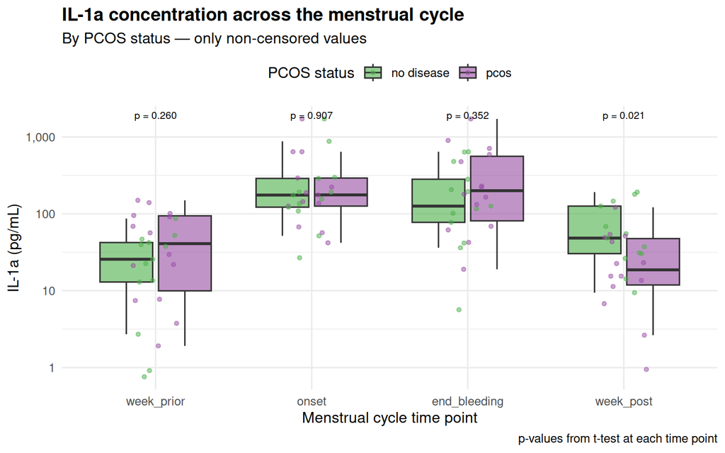

IL-1a concentration across the menstrual cycle, grouped by PCOS status

```r
pcos_colors <- c("no disease" = "#4DAF4A", "pcos" = "#984EA3")

il1a_plot_data <- luminex_master |>
  filter(cytokine == "IL-1a", limits == "not_censored")

p2 <- il1a_plot_data |>
  ggplot(aes(x = time_point, y = conc, fill = pcos_status)) +
  geom_boxplot(alpha = 0.6, outlier.shape = NA) +
  geom_jitter(aes(color = pcos_status), width = 0.15, alpha = 0.5, size = 1.2) +
  scale_fill_manual(values = pcos_colors) +
  scale_color_manual(values = pcos_colors) +
  scale_y_log10(labels = scales::comma) +
  labs(
    title = "IL-1a concentration across the menstrual cycle",
    subtitle = "By PCOS status — only non-censored values",
    x = "Menstrual cycle time point",
    y = "IL-1a (pg/mL)",
    fill = "PCOS status",
    color = "PCOS status",
    caption = "p-values from t-test at each time point"
  ) +
  theme_minimal(base_size = 12) +
  theme(
    plot.title = element_text(face = "bold"),
    legend.position = "top"
  )

p2 + stat_compare_means(
  aes(group = pcos_status),
  label = "p.format",
  method = "t.test",
  bracket.size = 0.3,
  size = 2.8,
  tip.length = 0.01
)
```

### Figure 3 — CD4/CD8 ratio (both arm and PCOS)

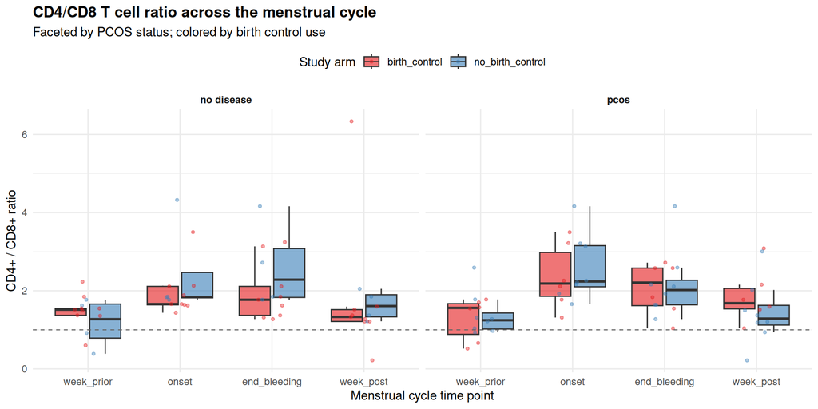

CD4/CD8 T cell ratio across the menstrual cycle, faceted by PCOS status and coloured by birth control use

```r
master |>
  ggplot(aes(x = time_point, y = cd4_cd8_ratio, fill = arm)) +
  geom_boxplot(alpha = 0.6, outlier.shape = NA) +
  geom_jitter(aes(color = arm), width = 0.15, alpha = 0.4, size = 1) +
  scale_fill_manual(values = arm_colors) +
  scale_color_manual(values = arm_colors) +
  geom_hline(yintercept = 1, linetype = "dashed", color = "grey40", linewidth = 0.4) +
  labs(
    title = "CD4/CD8 T cell ratio across the menstrual cycle",
    subtitle = "Faceted by PCOS status; colored by birth control use",
    x = "Menstrual cycle time point",
    y = "CD4+ / CD8+ ratio",
    fill = "Study arm",
    color = "Study arm"
  ) +
  facet_wrap(~ pcos_status) +
  theme_minimal(base_size = 11) +
  theme(
    plot.title = element_text(face = "bold"),
    legend.position = "top",
    strip.text = element_text(face = "bold")
  )
```

## Summary of key findings

| Finding | Evidence |
| --- | --- |
| **IL-1a varies dramatically across the cycle** | F<sub>3,73.8</sub> = 22.75, p < 0.001 — peaks at onset and end_bleeding |
| **Birth control lowers IL-1a** | F<sub>1,24.3</sub> = 6.96, p = 0.014 — lower concentrations in BC users |
| **CD4/CD8 ratio shifts across the cycle** | F<sub>3,75</sub> = 9.57, p < 0.001 — suggests differential T cell trafficking |
| **CD45+ cells and neutrophils are stable** | No significant effects of time, arm, or PCOS |
| **PCOS shows trends but not significant** | Possibly due to small sample size (n = 27) |

## Limitations & next steps

- **Small sample (n = 27)** limits power for detecting interaction effects
- **Censored cytokine data** — TNFa, IFNg, IL-1b mostly below detection — reduces usable observations
- **Birth control type not specified** (pill vs. IUD vs. implant may differ)
- **PCOS diagnosis method** not documented
- Next: censored regression (tobit) models, inclusion of age/sexual activity as covariates, pathway analysis linking cytokines to cell types